## Agenda

- add title and subtitle to the plot
- modify axis labels
- modify axis range
- remove axis
- format axis

## Libraries

```r
library(ggplot2)
library(dplyr)
library(tidyr)
```

## Basic Plot

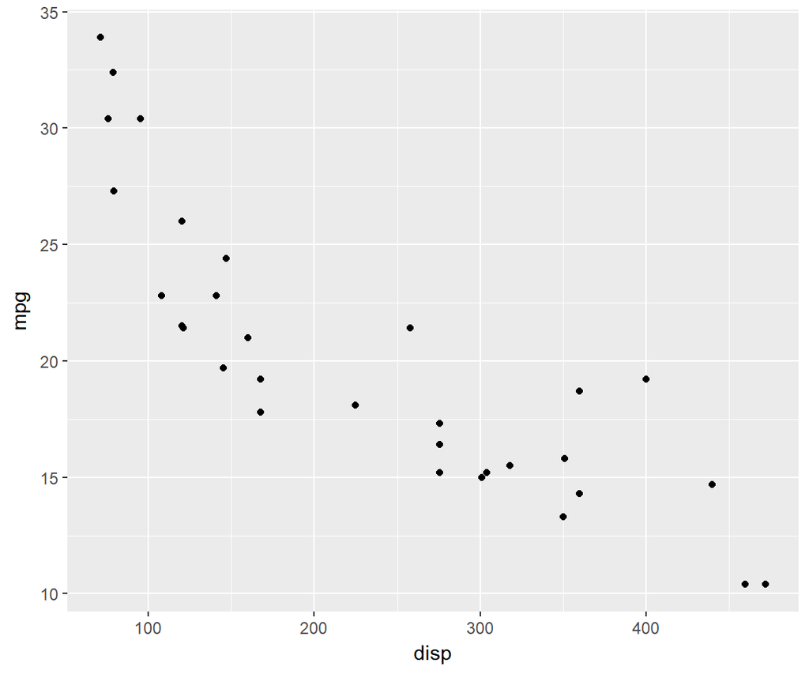

```r
ggplot(mtcars) +
  geom_point(aes(disp, mpg))
```

## Title & Subtitle

There are two ways to add title to a plot:

- `ggtitle()`
- `labs()`

## ggtitle()

Let us explore the `ggtitle()` function first. It takes two arguments:

- label: title of the plot
- subtitle: subtitle of the plot

## Title & Subtitle

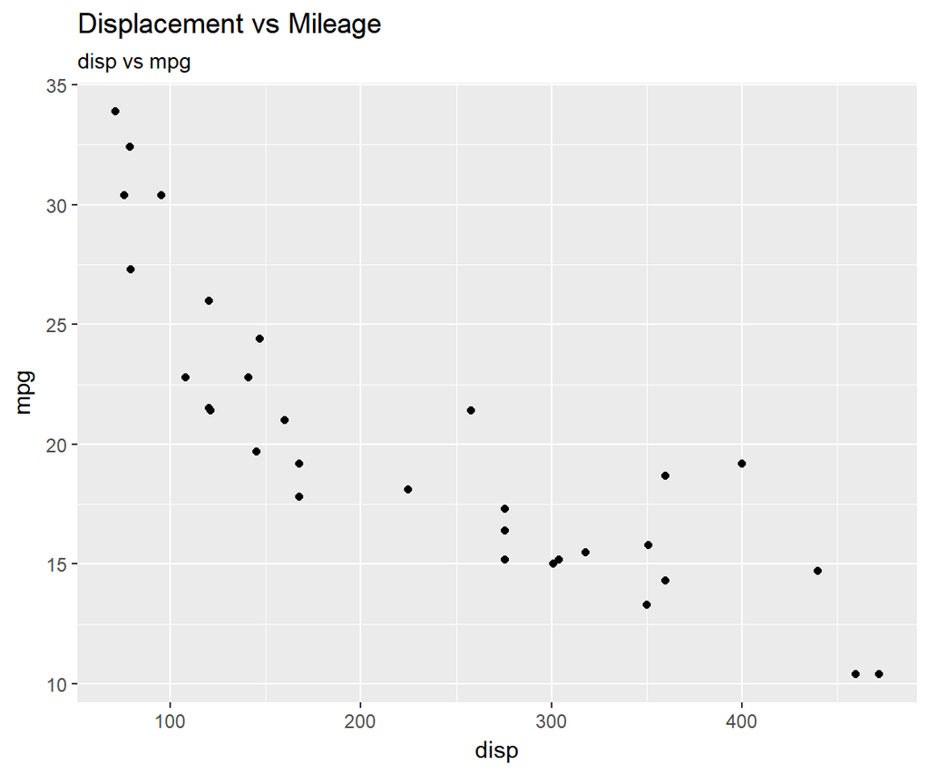

```r
ggplot(mtcars) +
  geom_point(aes(disp, mpg)) +
  ggtitle(label = 'Displacement vs Mileage', subtitle = 'disp vs mpg')
```

## Axis Labels

You can add labels to the axis using:

- `xlab()`
- `ylab()`
- `labs()`

## Axis Labels

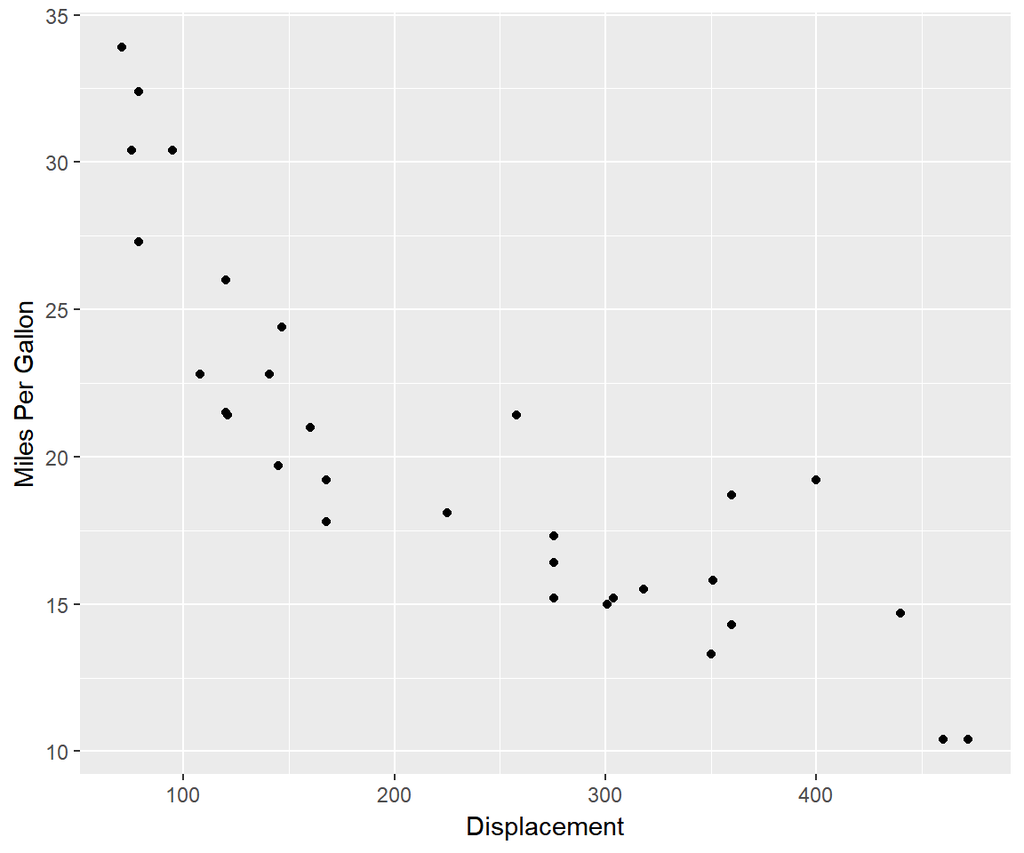

```r
ggplot(mtcars) +
  geom_point(aes(disp, mpg)) +
  xlab('Displacement') + ylab('Miles Per Gallon')
```

## Labs

The `labs()` function can be used to add the following to a plot:

- title
- subtitle
- X axis label
- Y axis label

## Labs

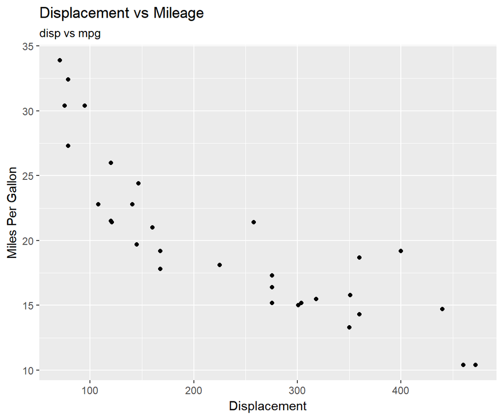

```r
ggplot(mtcars) +
  geom_point(aes(disp, mpg)) +
  labs(title = 'Displacement vs Mileage', subtitle = 'disp vs mpg',
    x = 'Displacement', y = 'Miles Per Gallon')
```

## Axis Range

In certain scenarios, you may want to modify the range of the axis. In ggplot2, we can achieve this using:

- `xlim()`
- `ylim()`
- `expand_limits()`

## Axis Range

- `xlim()` and `ylim()` take a numeric vector of length 2 as input
- `expand_limits()` takes two numeric vectors (each of length 2), one for each axis
- in all of the above functions, the first element represents the lower limit and the second element represents the upper limit

## X Axis

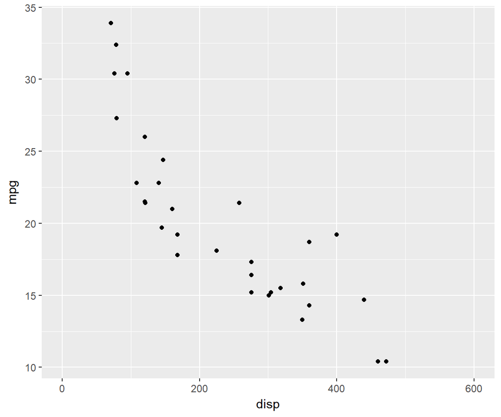

```r
ggplot(mtcars) +
  geom_point(aes(disp, mpg)) +
  xlim(c(0, 600))
```

## Y Axis

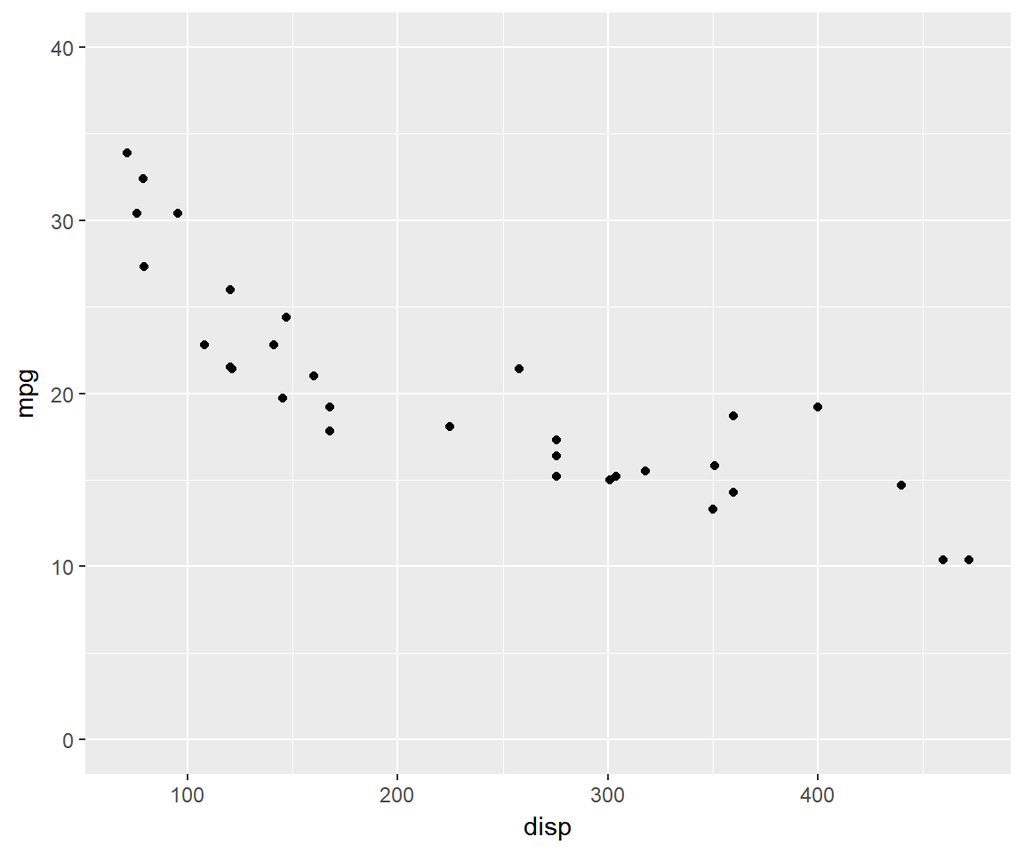

```r
ggplot(mtcars) +
  geom_point(aes(disp, mpg)) +
  ylim(c(0, 40))
```

## Expand Limits

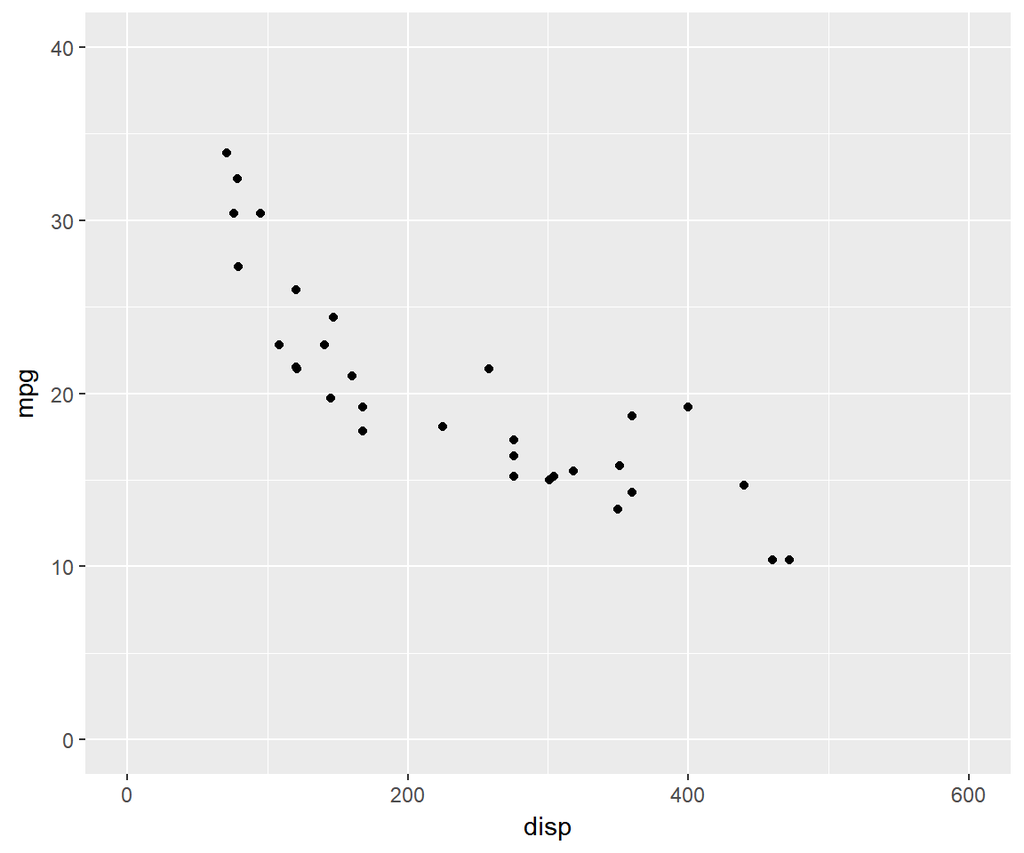

```r
ggplot(mtcars) +
  geom_point(aes(disp, mpg)) +
  expand_limits(x = c(0, 600), y = c(0, 40))
```

## Remove Axis Labels

If you want to remove the axis labels all together, use the `theme()` function. It allows us to modify every aspect of the theme of the plot. Within `theme()`, set the following to `element_blank()`.

- `axis.title.x`
- `axis.title.y`

## Remove Axis Labels using theme()

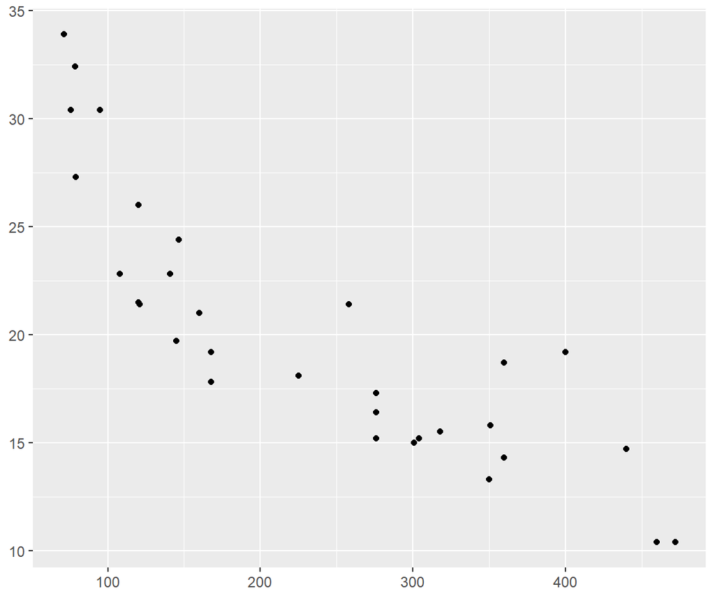

```r
ggplot(mtcars) +
  geom_point(aes(disp, mpg)) +
  theme(axis.title.x = element_blank(), axis.title.y = element_blank())
```

## Format Title & Axis Labels

To format the title or the axis labels, we have to modify the theme of the plot using the `theme()` function. We can modify:

- color
- font family
- font face
- font size
- horizontal alignment
- and angle

## Color

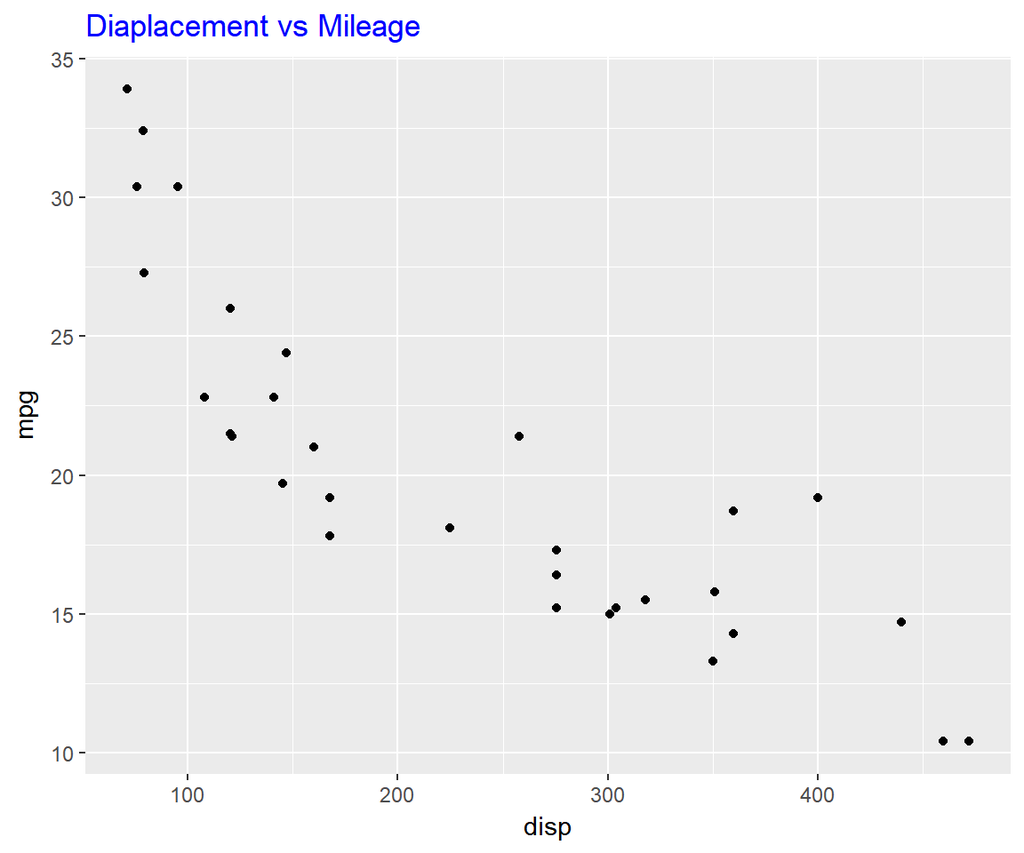

```r
ggplot(mtcars) +
  geom_point(aes(disp, mpg)) + ggtitle('Diaplacement vs Mileage') +
  theme(plot.title = element_text(color = 'blue'))
```

## Font Family

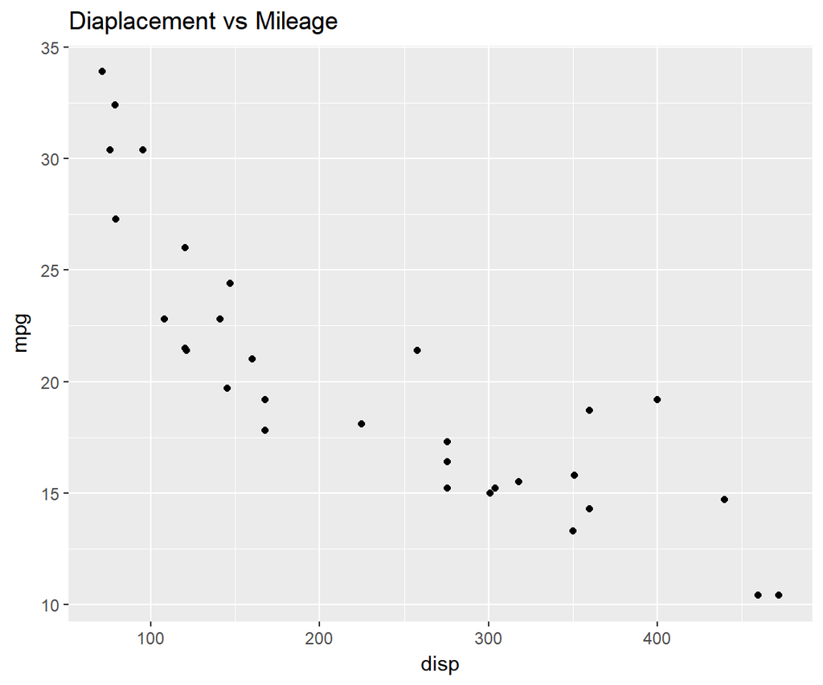

```r
ggplot(mtcars) +
  geom_point(aes(disp, mpg)) + ggtitle('Diaplacement vs Mileage') +
  theme(plot.title = element_text(family = 'Arial'))
```

## Font Face

The font face can be any of the following:

- `plain`
- `bold`
- `italic`
- `bold.italic`

## Font Face

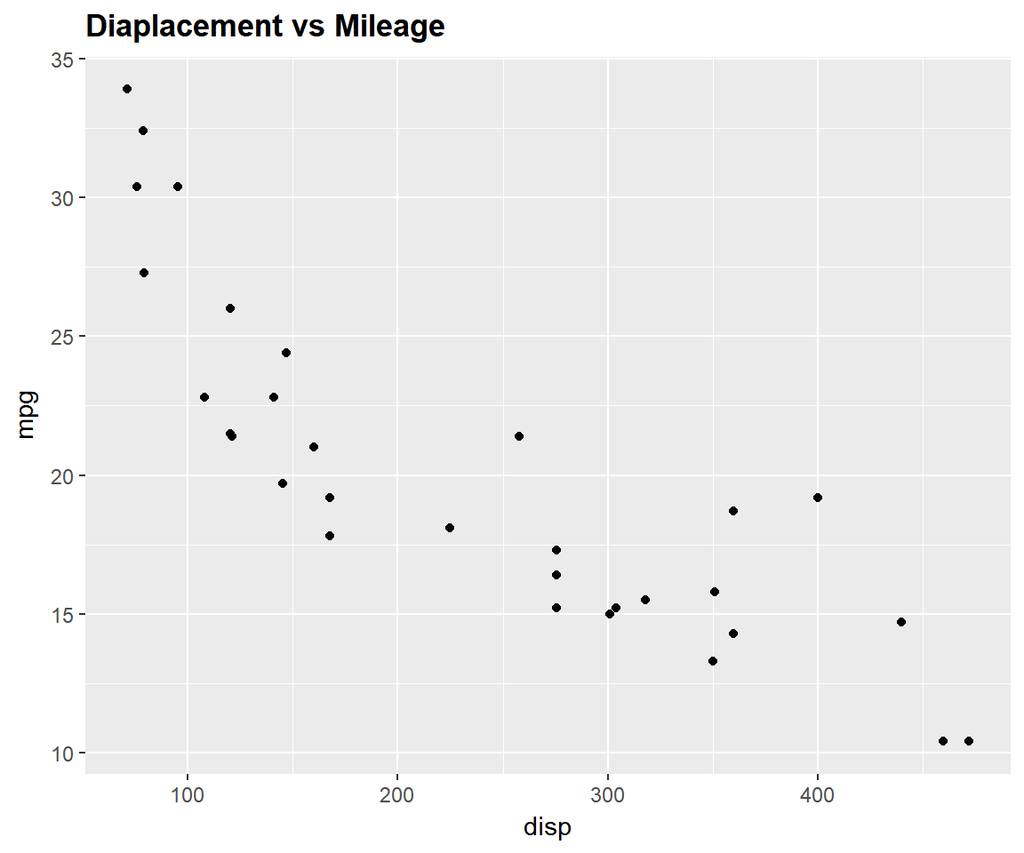

```r
ggplot(mtcars) +
  geom_point(aes(disp, mpg)) + ggtitle('Diaplacement vs Mileage') +
  theme(plot.title = element_text(face = 'bold'))
```

## Font Size

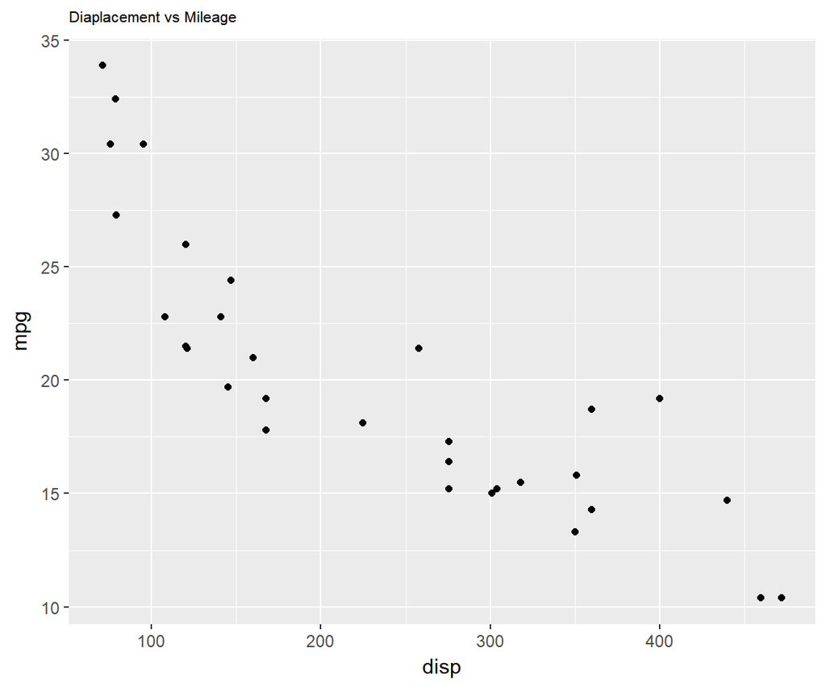

```r
ggplot(mtcars) +
  geom_point(aes(disp, mpg)) + ggtitle('Diaplacement vs Mileage') +
  theme(plot.title = element_text(size = 8))
```

## Horizontal Alignment

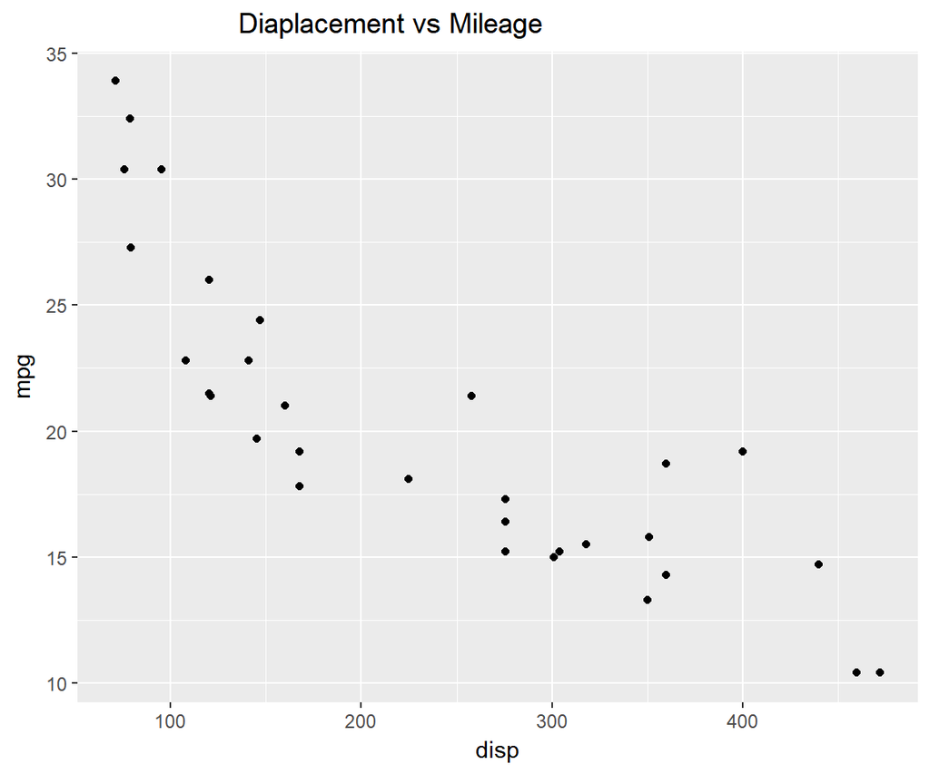

```r
ggplot(mtcars) +
  geom_point(aes(disp, mpg)) + ggtitle('Diaplacement vs Mileage') +
  theme(plot.title = element_text(hjust = 0.3))
```

## Title

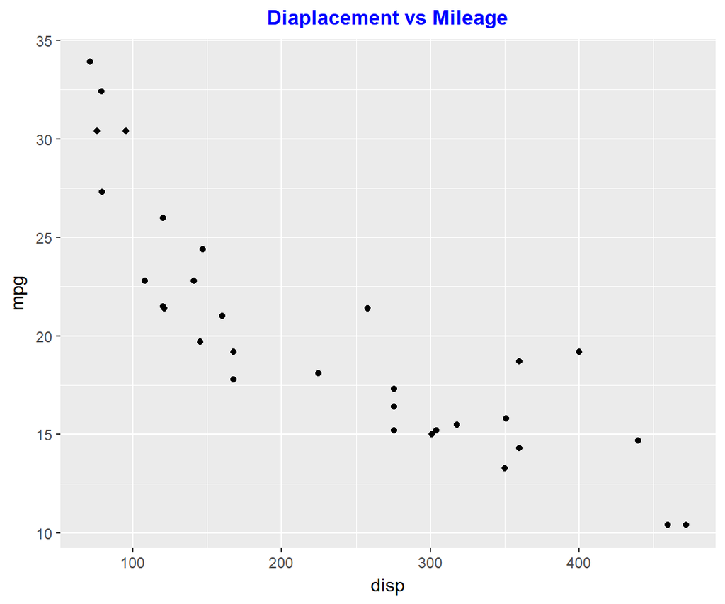

```r
ggplot(mtcars) +
  geom_point(aes(disp, mpg)) + ggtitle('Diaplacement vs Mileage') +
  theme(plot.title = element_text(color = 'blue', family = 'Arial',
    face = 'bold', size = 12, hjust = 0.5))
```

## Putting it all together.. X Axis

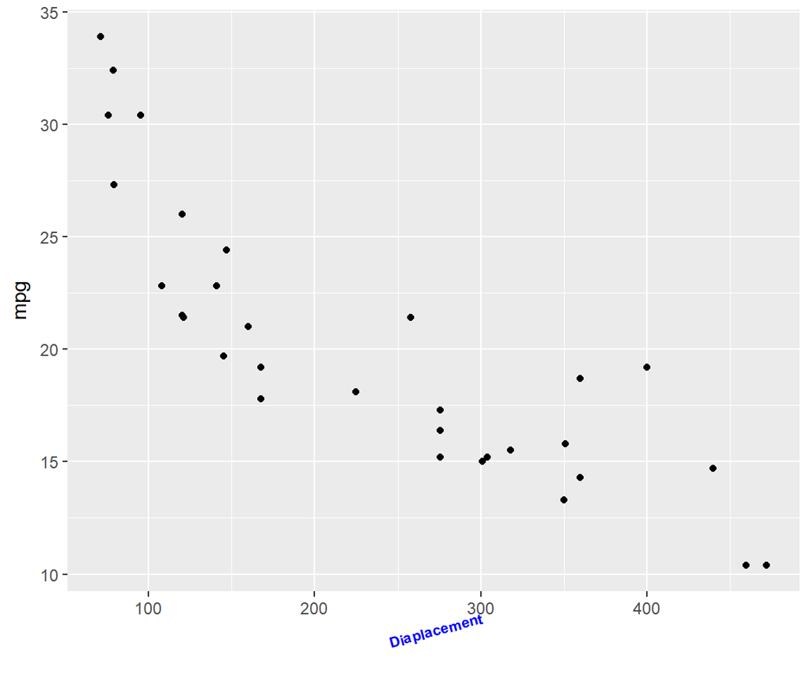

```r
ggplot(mtcars) +
  geom_point(aes(disp, mpg)) + xlab('Diaplacement') +
  theme(axis.title.x = element_text(color = 'blue', family = 'Arial',
    face = 'bold', size = 8, hjust = 0.5, angle = 15))
```

## Putting it all together.. Y Axis

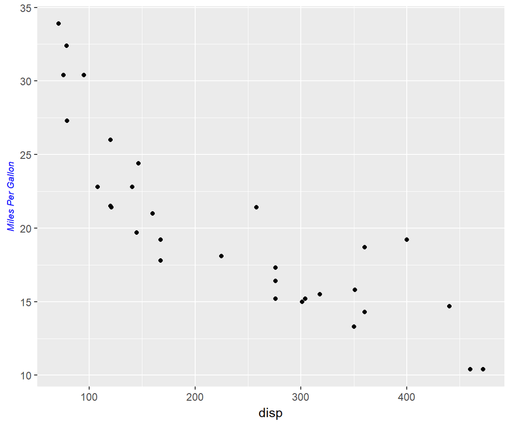

```r
ggplot(mtcars) +
  geom_point(aes(disp, mpg)) + ylab('Miles Per Gallon') +
  theme(axis.title.y = element_text(color = 'blue', family = 'Arial',
    face = 'italic', size = 8, vjust = 0.3, angle = 90))
```